# ML3

Wytze Vlietstra

11/27/2017

# Introduction

Based on our skype call of Monday 27-11-2017, we agreed upon a number of further experiments which have either been skipped, or which are requested to be added.

Specifically, we focus on the availability of the “direct” relationships, and the ratio between the positive and the negative cases. Furthermore, Rein requested a number of additional experiments which vary the distributions between the positive cases and the negative cases, and with the highly correlating features.

# Machine learning experiments

We perform further experiments with the random forests package, because in previous experiments it performed best. However, the analysis algorithm can be swapped out with relatively little effort.

## Classifying the instances that have a direct/indirect relationship separately

To examine whether there are differences between the instances that have a direct relationship, and the ones that only have an indirect relationship, we perform several experiments. First, we split up the dataset according to the availability of the direct relationship, and examine its effect on the classificaton.

```r
# Direct
direct = all[all$direct == TRUE, ]
direct_gs = factor(direct$goldstandard, levels = c("VALID", "INVALID"))
direct = direct[,-which(colnames(direct) %in% exclusion_columns)]

direct_model = train(x = direct, y = direct_gs, method = "rf",
              trControl=trainControl(method="cv",number=10, classProbs = TRUE,
              savePredictions = TRUE, summaryFunction = twoClassSummary),
              prox=TRUE, allowParallel=TRUE, metric = "ROC")

kable(direct_model$results[direct_model$results$mtry == direct_model$bestTune$mtry, c("ROC", "Sens", "Spec")])
```

|  | ROC | Sens | Spec |
| --- | --- | --- | --- |
| 2 | 0.946486 | 0.9415331 | 0.7835759 |

```r
# Indirect
indirect = all[all$direct == FALSE, ]
indirect_gs = factor(indirect$goldstandard, levels = c("VALID", "INVALID"))
indirect = indirect[,-which(colnames(indirect) %in% exclusion_columns)]

indirect_model = train(x = indirect, y = indirect_gs, method = "rf",
              trControl=trainControl(method="cv",number=10, classProbs = TRUE,
              savePredictions = TRUE, summaryFunction = twoClassSummary),
              prox=TRUE, allowParallel=TRUE, metric = "ROC")

kable(indirect_model$results[indirect_model$results$mtry == indirect_model$bestTune$mtry, c("ROC", "Sens", "Spec")])
```

|  | ROC | Sens | Spec |
| --- | --- | --- | --- |
| 2 | 0.9616196 | 0.9533409 | 0.8181651 |

As can be seen, there is little effect on the classification performance. The distribution between positive and negative cases between the stratified datasets appears to be similar as that of the complete dataset.

```r
# Positive cases
direct_distribution = table(direct_gs)

print(round(direct_distribution["VALID"] / direct_distribution["INVALID"], 3))
```

```
## VALID
## 2.065
```

```r
# Negative cases
indirect_distribution = table(indirect_gs)

print(round(indirect_distribution["VALID"] / indirect_distribution["INVALID"], 3))
```

```
## VALID
## 2.109
```

## Crossover

In this experiment we classify the positive cases with a direct relationship against the negative cases with only indirect relationships to identify potential differences between the classes.

```r
# Create the feature sets
cross_pos_neg = rbind.fill(pos[pos$direct == "True", ], neg[neg$direct == "False", ])
cross_neg_pos = rbind.fill(pos[pos$direct == "False", ], neg[neg$direct == "True", ])
cross_pos_neg[is.na(cross_pos_neg)] = 0
cross_neg_pos[is.na(cross_neg_pos)] = 0

cross_pos_neg_gs = cross_pos_neg$goldstandard
cross_neg_pos_gs = cross_neg_pos$goldstandard

cross_pos_neg = cross_pos_neg[,-which(colnames(cross_pos_neg) %in% exclusion_columns)]
cross_pos_neg$direct = NULL

cross_neg_pos = cross_neg_pos[,-which(colnames(cross_neg_pos) %in% exclusion_columns)]
cross_neg_pos$direct = NULL

cross_pn_model = train(x = cross_pos_neg, y = cross_pos_neg_gs, method = "rf",
                  trControl=trainControl(method="cv",number=10, classProbs = TRUE,
                  savePredictions = TRUE, summaryFunction = twoClassSummary),
                  prox=TRUE, allowParallel=TRUE, metric = "ROC")

kable(cross_pn_model$results[cross_pn_model$results$mtry == cross_pn_model$bestTune$mtry, c("ROC", "Sens", "Spec")])
```

|  | ROC | Sens | Spec |
| --- | --- | --- | --- |
| 2 | 0.9816932 | 0.8914552 | 0.9752756 |

```r
cross_np_model = train(x = cross_neg_pos, y = cross_neg_pos_gs, method = "rf",
                  trControl=trainControl(method="cv",number=10, classProbs = TRUE,
                  savePredictions = TRUE, summaryFunction = twoClassSummary),
                  prox=TRUE, allowParallel=TRUE, metric = "ROC")

kable(cross_np_model$results[cross_np_model$results$mtry == cross_np_model$bestTune$mtry, c("ROC", "Sens", "Spec")])
```

|  | ROC | Sens | Spec |
| --- | --- | --- | --- |
| 2 | 0.9932415 | 0.9295306 | 0.9797324 |

As can be seen, when the direct/indirect and positive/negative cases are crossed over, performance is almost perfect.

## Internal

Finally, as a last control we classify the positive cases with direct relationships against the positive cases with only indirect relationships, to identify potential differences between them. For this experiments, the “direct” feature is ofcourse removed.

```r
# Positive cases
pos_input = pos[,-which(colnames(pos) %in% exclusion_columns)]
pos_gs = ifelse(pos$direct == "True", "DIRECT", "INDIRECT")
pos_input$direct = NULL

pos_direct_model = train(x = pos_input, y = pos_gs, method = "rf",
              trControl=trainControl(method="cv",number=10, classProbs = TRUE,
              savePredictions = TRUE, summaryFunction = twoClassSummary),
              prox=TRUE, allowParallel=TRUE, metric = "ROC")

kable(pos_direct_model$results[pos_direct_model$results$mtry == pos_direct_model$bestTune$mtry, c("ROC", "Sens", "Spec")])
```

|  | ROC | Sens | Spec |
| --- | --- | --- | --- |
| 2 | 0.9402572 | 0.8696912 | 0.8613173 |

```r
# Negative cases
neg_input = neg[,-which(colnames(neg) %in% exclusion_columns)]
neg_gs = ifelse(neg$direct == "True", "DIRECT", "INDIRECT")
neg_input$direct = NULL

neg_direct_model = train(x = neg_input, y = neg_gs, method = "rf",
              trControl=trainControl(method="cv",number=10, classProbs = TRUE,
              savePredictions = TRUE, summaryFunction = twoClassSummary),
              prox=TRUE, allowParallel=TRUE, metric = "ROC")

kable(neg_direct_model$results[neg_direct_model$results$mtry == neg_direct_model$bestTune$mtry, c("ROC", "Sens", "Spec")])
```

|  | ROC | Sens | Spec |
| --- | --- | --- | --- |
| 2 | 0.979607 | 0.9384081 | 0.9050285 |

Here we see something interesting. Apparently, there are structural differences between the instances that have a direct relationship, and the ones that do not have one. This would also explain the almost perfect performance we saw in the previous experiment.

First, we see if this is not simply a case of there being more available information.

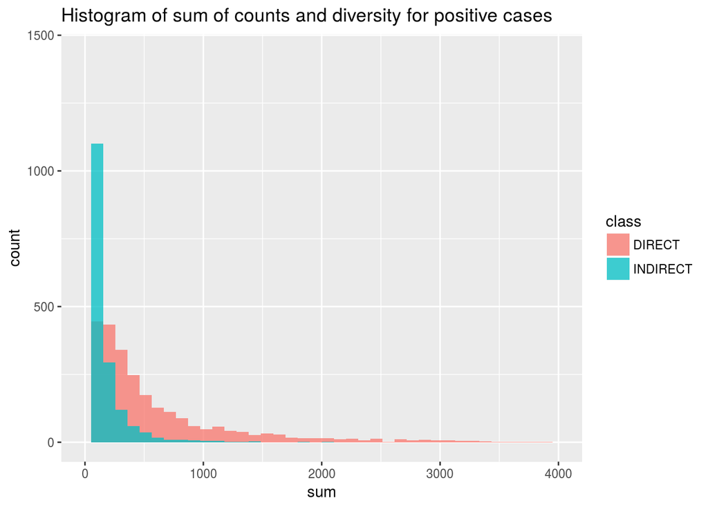

```r
pos_row_sum = data.frame(sum = rowSums(pos_input), class = pos_gs)
neg_row_sum = data.frame(sum = rowSums(neg_input), class = neg_gs)

ggplot(data = pos_row_sum) + geom_histogram(aes(x = sum, fill = class), bins = 40, alpha = 0.75, position = "identity") + xlim(0, 4000) + ggtitle("Histogram of sum of counts and diversity for positive cases")
```

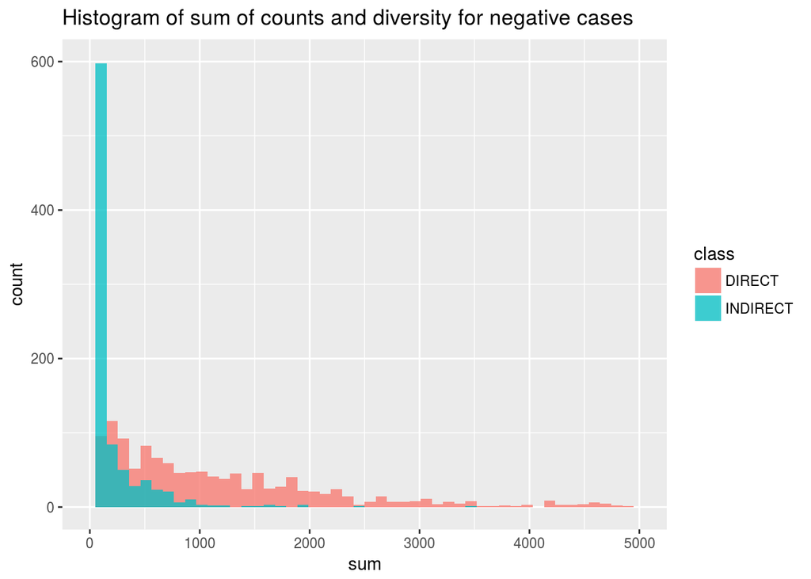

```r
ggplot(data = neg_row_sum) + geom_histogram(aes(x = sum, fill = class), bins = 50, alpha = 0.75, position = "identity") +  ggtitle("Histogram of sum of counts and diversity for negative cases") + xlim(0,5000)
```

As can be seen, the instances with a direct relationship have a lot more information available. Because they are likely to be better investigated, this is not unexpected.

Next, we investigate which features are most predictive for this classification.

```r
# Positive cases
pos_varImp = data.frame(Feature = rownames(varImp(pos_direct_model)$importance), score = varImp(pos_direct_model)$importance$Overall)
pos_varImp = pos_varImp[order(pos_varImp$score, decreasing = T), ]

# Negative cases
neg_varImp = data.frame(Feature = rownames(varImp(neg_direct_model)$importance), score = varImp(neg_direct_model)$importance$Overall)
neg_varImp = neg_varImp[order(neg_varImp$score, decreasing = T), ]

overlappers = unique(c(as.character(neg_varImp$Feature[1:5]), as.character(pos_varImp$Feature[1:5])))

print(length(overlappers))
```

```
## [1] 5
```

If we look at the top 5 most important features between the positive and negative cases, we see they are completely identical

Finally, we check how well we can classify based on these features by creating ROC curves. The black curve is for the positive cases, and the red one for the negative cases.

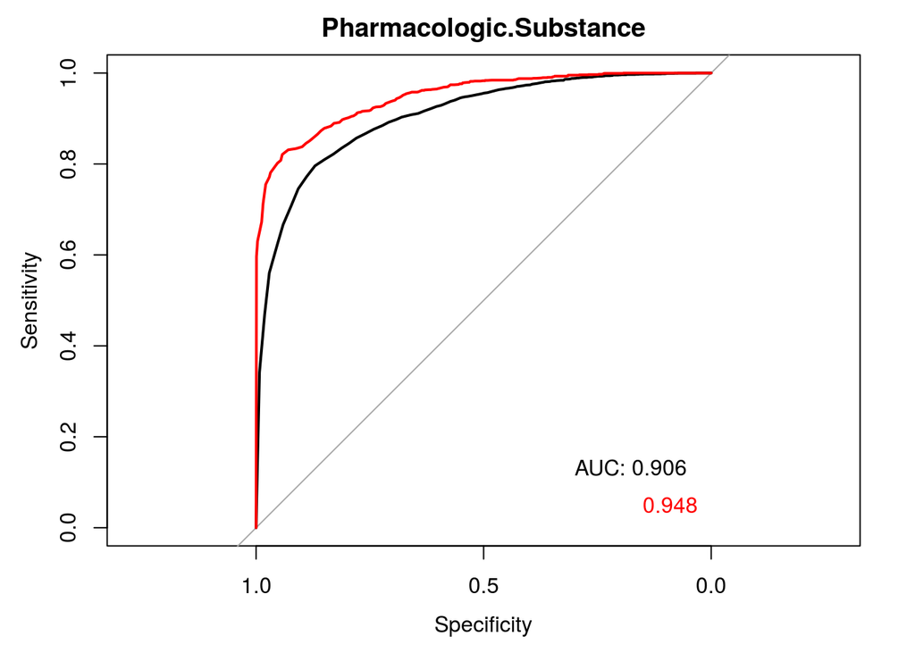

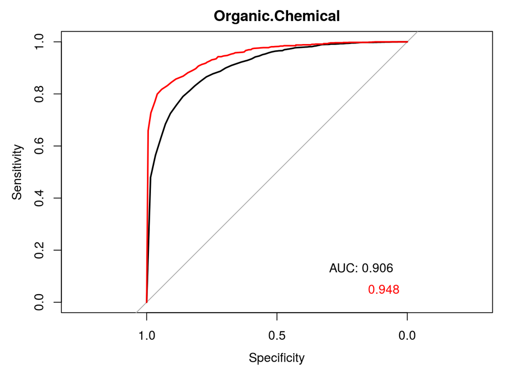

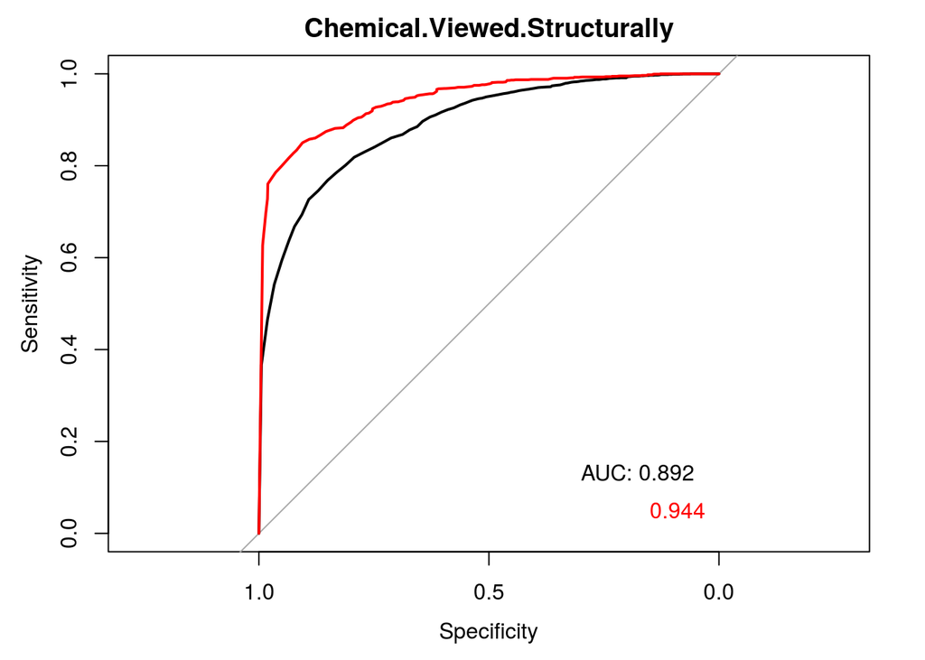

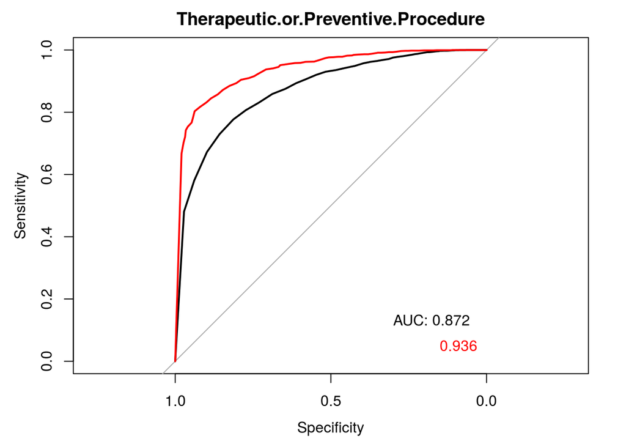

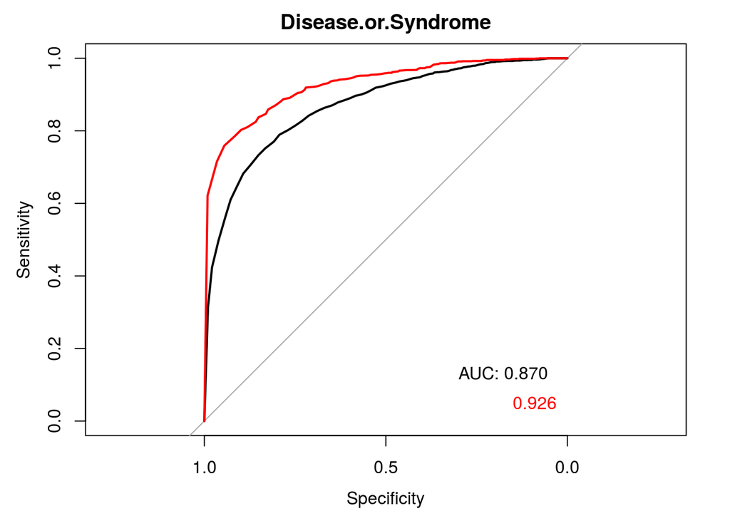

```r
for(i in seq_along(overlappers)){
  plot(roc(pos_gs, pos_input[,overlappers[i]]), print.auc = T, print.auc.x = 0.3, print.auc.y = 0.15, main = overlappers[i])
  lines(roc(neg_gs, neg_input[,overlappers[i]]), col = "red")
  text(x = 0.09, y = 0.05, labels = round(as.numeric(roc(neg_gs, neg_input[,overlappers[i]])$auc), 3), col = "red")
}
```

As can be seen, each these features is already highly predictive for a direct relationship between a drug and a diseases.

# Additional experiments for Rein

Rein requested some additional experiments, which will be described in these final sections First, I vary the class distribution between the positive and the negative cases. Then, I re-examine the highly correlating features.

## Varying the class distributions

Some variations in distributions already occur naturally, (e.g. 2:1 pos/neg), which I therefore skip. Another one I skip as well is the 1:1, which I performed in the previous document.

### 5:1 positive/negative

```r
distribution = table(goldstandard)

pos_indx = sample(which(goldstandard == "VALID"), distribution["VALID"])
neg_indx = sample(which(goldstandard == "INVALID"), distribution["VALID"] * 1 / 5)

sampled_set = feature_set[c(pos_indx, neg_indx), ]
sampled_gs = goldstandard[c(pos_indx, neg_indx)]

sampled_model = train(x = sampled_set, y = sampled_gs, method = "rf",
              trControl=trainControl(method="cv",number=10, classProbs = TRUE,
              savePredictions = TRUE, summaryFunction = twoClassSummary),
              prox=TRUE, allowParallel=TRUE, metric = "ROC")

kable(sampled_model$results[sampled_model$results$mtry == sampled_model$bestTune$mtry, c("ROC", "Sens", "Spec")])
```

|  | ROC | Sens | Spec |
| --- | --- | --- | --- |
| 2 | 0.9441708 | 0.9779002 | 0.6622108 |

### 4:1 positive/negative

```r
pos_indx = sample(which(goldstandard == "VALID"), distribution["VALID"])
neg_indx = sample(which(goldstandard == "INVALID"), distribution["VALID"] * 1 / 4)

sampled_set = feature_set[c(pos_indx, neg_indx), ]
sampled_gs = goldstandard[c(pos_indx, neg_indx)]

sampled_model = train(x = sampled_set, y = sampled_gs, method = "rf",
              trControl=trainControl(method="cv",number=10, classProbs = TRUE,
              savePredictions = TRUE, summaryFunction = twoClassSummary),
              prox=TRUE, allowParallel=TRUE, metric = "ROC")

kable(sampled_model$results[sampled_model$results$mtry == sampled_model$bestTune$mtry, c("ROC", "Sens", "Spec")])
```

|  | ROC | Sens | Spec |
| --- | --- | --- | --- |
| 2 | 0.9456578 | 0.9731271 | 0.7107582 |

### 3:2 positive/negative

```r
pos_indx = sample(which(goldstandard == "VALID"), distribution["INVALID"] * 3 / 2)
neg_indx = sample(which(goldstandard == "INVALID"), distribution["INVALID"])

sampled_set = feature_set[c(pos_indx, neg_indx), ]
sampled_gs = goldstandard[c(pos_indx, neg_indx)]

sampled_model = train(x = sampled_set, y = sampled_gs, method = "rf",
              trControl=trainControl(method="cv",number=10, classProbs = TRUE,
              savePredictions = TRUE, summaryFunction = twoClassSummary),
              prox=TRUE, allowParallel=TRUE, metric = "ROC")

kable(sampled_model$results[sampled_model$results$mtry == sampled_model$bestTune$mtry, c("ROC", "Sens", "Spec")])
```

|  | ROC | Sens | Spec |
| --- | --- | --- | --- |
| 2 | 0.9531564 | 0.9256533 | 0.836407 |

### 1:2 positive/negative

```r
pos_indx = sample(which(goldstandard == "VALID"), distribution["INVALID"] * 1 / 2)
neg_indx = sample(which(goldstandard == "INVALID"), distribution["INVALID"])

sampled_set = feature_set[c(pos_indx, neg_indx), ]
sampled_gs = goldstandard[c(pos_indx, neg_indx)]

sampled_model = train(x = sampled_set, y = sampled_gs, method = "rf",
              trControl=trainControl(method="cv",number=10, classProbs = TRUE,
              savePredictions = TRUE, summaryFunction = twoClassSummary),
              prox=TRUE, allowParallel=TRUE, metric = "ROC")

kable(sampled_model$results[sampled_model$results$mtry == sampled_model$bestTune$mtry, c("ROC", "Sens", "Spec")])
```

|  | ROC | Sens | Spec |
| --- | --- | --- | --- |
| 2 | 0.9478844 | 0.7902996 | 0.9246508 |

### 1:3 positive/negative

```r
pos_indx = sample(which(goldstandard == "VALID"), distribution["INVALID"] * 1 / 3)
neg_indx = sample(which(goldstandard == "INVALID"), distribution["INVALID"])

sampled_set = feature_set[c(pos_indx, neg_indx), ]
sampled_gs = goldstandard[c(pos_indx, neg_indx)]

sampled_model = train(x = sampled_set, y = sampled_gs, method = "rf",
              trControl=trainControl(method="cv",number=10, classProbs = TRUE,
              savePredictions = TRUE, summaryFunction = twoClassSummary),
              prox=TRUE, allowParallel=TRUE, metric = "ROC")

kable(sampled_model$results[sampled_model$results$mtry == sampled_model$bestTune$mtry, c("ROC", "Sens", "Spec")])
```

|  | ROC | Sens | Spec |
| --- | --- | --- | --- |
| 2 | 0.94318 | 0.6873871 | 0.954946 |

### 2:3 positive/negative

```r
pos_indx = sample(which(goldstandard == "VALID"), distribution["INVALID"] * 2 / 3)
neg_indx = sample(which(goldstandard == "INVALID"), distribution["INVALID"])

sampled_set = feature_set[c(pos_indx, neg_indx), ]
sampled_gs = goldstandard[c(pos_indx, neg_indx)]

sampled_model = train(x = sampled_set, y = sampled_gs, method = "rf",
              trControl=trainControl(method="cv",number=10, classProbs = TRUE,
              savePredictions = TRUE, summaryFunction = twoClassSummary),
              prox=TRUE, allowParallel=TRUE, metric = "ROC")

kable(sampled_model$results[sampled_model$results$mtry == sampled_model$bestTune$mtry, c("ROC", "Sens", "Spec")])
```

|  | ROC | Sens | Spec |
| --- | --- | --- | --- |
| 2 | 0.9499683 | 0.8376796 | 0.9036258 |

### 1:4 positive/negative

```r
pos_indx = sample(which(goldstandard == "VALID"), distribution["INVALID"] * 1 / 4)
neg_indx = sample(which(goldstandard == "INVALID"), distribution["INVALID"])

sampled_set = feature_set[c(pos_indx, neg_indx), ]
sampled_gs = goldstandard[c(pos_indx, neg_indx)]

sampled_model = train(x = sampled_set, y = sampled_gs, method = "rf",
              trControl=trainControl(method="cv",number=10, classProbs = TRUE,
              savePredictions = TRUE, summaryFunction = twoClassSummary),
              prox=TRUE, allowParallel=TRUE, metric = "ROC")

kable(sampled_model$results[sampled_model$results$mtry == sampled_model$bestTune$mtry, c("ROC", "Sens", "Spec")])
```

|  | ROC | Sens | Spec |
| --- | --- | --- | --- |
| 2 | 0.9400684 | 0.5981563 | 0.9689832 |

### 1:5 positive/negative

```r
pos_indx = sample(which(goldstandard == "VALID"), distribution["INVALID"] * 1 / 5)
neg_indx = sample(which(goldstandard == "INVALID"), distribution["INVALID"])

sampled_set = feature_set[c(pos_indx, neg_indx), ]
sampled_gs = goldstandard[c(pos_indx, neg_indx)]

sampled_model = train(x = sampled_set, y = sampled_gs, method = "rf",
              trControl=trainControl(method="cv",number=10, classProbs = TRUE,
              savePredictions = TRUE, summaryFunction = twoClassSummary),
              prox=TRUE, allowParallel=TRUE, metric = "ROC")

kable(sampled_model$results[sampled_model$results$mtry == sampled_model$bestTune$mtry, c("ROC", "Sens", "Spec")])
```

|  | ROC | Sens | Spec |
| --- | --- | --- | --- |
| 2 | 0.9418374 | 0.576633 | 0.975997 |

## Re-examining the highly correlating features

I re-examined the highly correlating features to see how they perform independently. For this, I select only the features which correlate higher than 0.8.

```r
reduced_set = feature_set[,which(colnames(feature_set) %in% unlist(feature_combos[feature_combos$correlation > 0.8, c("A", "B")]))]

reduced_model = train(x = reduced_set, y = goldstandard, method = "rf",
              trControl=trainControl(method="cv",number=10, classProbs = TRUE,
              savePredictions = TRUE, summaryFunction = twoClassSummary),
              prox=TRUE, allowParallel=TRUE, metric = "ROC")

kable(reduced_model$results[reduced_model$results$mtry == reduced_model$bestTune$mtry, c("ROC", "Sens", "Spec")])
```

|  | ROC | Sens | Spec |
| --- | --- | --- | --- |
| 2 | 0.9307559 | 0.9344113 | 0.7629042 |

These highly correlating features alone, all 39 of them, already achieve a high performance.

I take a sample of 10 of these highly correlating features, just to see how far I can push it.

```r
feature_sample = sample(unlist(feature_combos[feature_combos$correlation > 0.8, c("A", "B")]), 10)

reduced_set = feature_set[,which(colnames(feature_set) %in% feature_sample)]

reduced_model = train(x = reduced_set, y = goldstandard, method = "rf",
              trControl=trainControl(method="cv",number=10, classProbs = TRUE,
              savePredictions = TRUE, summaryFunction = twoClassSummary),
              prox=TRUE, allowParallel=TRUE, metric = "ROC")

kable(reduced_model$results[reduced_model$results$mtry == reduced_model$bestTune$mtry, c("ROC", "Sens", "Spec")])
```

|  | ROC | Sens | Spec |
| --- | --- | --- | --- |
| 2 | 0.8070591 | 0.8868461 | 0.6144704 |

Even with only 10 features, performance remains high. Further reduction (not shown) crashes performance ot about 0.6 AUC.

# Session info